# data management

me

9 joulukuuta 2019

# 1. Peltosirkkuaineiston muokkaus

## 1.1 Uusien muuttujien laskeminen

Lasketaan uusia muuttujia, jotka tiivistävät aineistoa. Osa muuttujista on “vaihtoehtoisia”, niiden sisältämä tieto saattaa kuulua kahteen eri muuttujaan.

### 1.1.1 Aineisto sisälle ja tarkastelu

```r
getwd()
```

```
## [1] "C:/Users/U1701911/OneDrive - University of Helsinki/github_mallinnus/ortolan_bunting"
```

```r
localDir = "."
DataDir = file.path(localDir, "data")
filename1 = file.path(DataDir, "osapop_20002018.csv")
filename2= file.path(DataDir,"keskipisteiden_koordinaatit.csv")
data = read.csv(filename1, sep=";")
koord = read.csv(filename2, sep=";")

names(data)
```

```
##   [1] "id"     "year"   "site"   "agri5"  "area"   "build"  "ndvi"
##   [8] "prec"   "river"  "roads"  "stream" "temp"   "terri"  "spnum"
##  [15] "X10"    "X50"    "X55"    "X60"    "X63"    "X90"    "X94"
##  [22] "X95"    "X1110"  "X1120"  "X1140"  "X1141"  "X1142"  "X1210"
##  [29] "X1211"  "X1220"  "X1230"  "X1310"  "X1320"  "X1330"  "X1400"
##  [36] "X1510"  "X1540"  "X1545"  "X1600"  "X1601"  "X1602"  "X1603"
##  [43] "X1605"  "X1700"  "X1750"  "X1800"  "X1810"  "X1900"  "X2110"
##  [50] "X2120"  "X2130"  "X2140"  "X2150"  "X2160"  "X2180"  "X2185"
##  [57] "X2190"  "X2195"  "X2196"  "X2197"  "X2200"  "X2400"  "X2410"
##  [64] "X2420"  "X2430"  "X2500"  "X2600"  "X3110"  "X3120"  "X3130"
##  [71] "X3140"  "X3150"  "X3160"  "X3180"  "X3190"  "X3210"  "X3310"
##  [78] "X4030"  "X4110"  "X4120"  "X4210"  "X4220"  "X4300"  "X4390"
##  [85] "X4520"  "X4530"  "X4610"  "X4620"  "X4800"  "X4810"  "X4900"
##  [92] "X4901"  "X4902"  "X4903"  "X4904"  "X5100"  "X5101"  "X5102"
##  [99] "X5103"  "X5104"  "X5105"  "X5106"  "X5107"  "X5108"  "X5109"
```

[output cut: 21 more lines]

Muuttujien selitykset:

id = kunkin osapopulaation yksilöivä id-numero (vuosien 2000-2017 välillä tehdyt havaintoryppäät, jotka tulkitaan lauluryhmäksi)

site = osapopulaation sijainti

agri5 = osapopulaation keskipisteen ympärille piirretyn 5 km säteen omaavan ympyrän sisälle jäävän maaseutu-maanpeitteen osuus (aineisto: Corine)

area = kunkin osapopulaation pinta-ala neliömetreissä (osapopulaatioksi tulkittujen havaintojen ympärille piirretty 300 metrin bufferi)

build = rakennusten lukumäärä osapopulaation alueella

river = jokien pituus metreinä

roads = teiden pituus metreinä

stream = purojen pituus metreinä

ndvi = Guinean edellistalven kasvillisuus-indeksi

prec = edellisen kesän (21.5-15.7) päivittäisten keskisadantojen keskiarvo osapopulaation alueella

temp = edelliskesän lämpötilat

terri = reviirien lukumäärä osapopulaation alueella vuosittain

spnum = viljelykasvien lukumäärä (ilman luokkaa 99999, eli ei tietoa)

X… = viljelykasviluokkien osuudet, Huom! muuttuja X99999 on “ei tietoa viljelykasvista”

Eri viljelykasveja on mukana yli toistasataa! Suurin osa tietysti nollaa.

Koordinaatit tulivat eri tiedostosta:

```r
head(koord)
```

```
##          X       Y id                             alue
## 1 416510.3 6714497  1              Maentsaelae, Purola
## 2 451751.2 6740100  2         Orimattila, Korpistonoja
## 3 422221.1 6725615  3          Pukkila, Savijoki, ydin
## 4 423032.5 6727459  4                 Pukkila, Suomela
## 5 422232.1 6722946  5               Pukkila, Naarkoski
## 6 419943.0 6719118  6 Pukkila, Maettaehistae, Suokanta
```

### 1.1.2 Shannon-Wienerin indeksi

Shannon-Wienerin indeksin laskeminen viljylykasvidiversiteetille. Mukaan laskuihin on (kai) otettava muuttuja ‘99999’ eli ‘ei tietoa kasvilajista’ koska muuten osuudet eivät summaudu yhteen.

```r
#lisataan shannon-wiener muuttuja
data<-mutate(data, shan = diversity(data[,15:248],index="shannon"))
```

### 1.1.3 Viljelykasvilajien lukumäärä

Kasvilajien lukumäärä (‘99999’ mukana). Huomioi, että todellisuudessa tämä muuttuja voi kuvastaa vain EU-tukiryhmien moninaisuutta, lajithan voivat olla samaa nurmea koko ajan mutta eri kategorioissa.

```r
#kasvilajien lukumaara
data<-mutate(data, snum= rowSums(data[,15:248]>0))
```

### 1.1.4 Viljelykasvilajien osuudet peltopinta-alasta

Alustava jaottelu kymmeneen ryhmään:

```r
#listataan ensi mita muuttujia menee mihinkin ryhmaan

eitietoa<-c("X99999")

avomaavih<-c("X5148","X3210","X50","X55","X3110","X3120","X3130","X3140","X3150","X3160","X3180","X3190","X3310","X5100","X5103","X5104","X5105","X5106","X5107","X5108","X5109","X5111","X5112","X5113","X5115","X5116","X5117","X5119","X5120","X5121","X5124","X5125","X5128","X5129","X5134","X5140","X5143","X5146","X5149","X5150","X5157","X5165","X5173","X5197","X5198","X5816","X9630")

erikois<-c("X4900","X4901","X4902","X4903","X4904","X9640","X9642") #lähinnä ruokohelpi (4900)

marjat<-c("X5210","X5213","X5220","X5221","X5301","X5302","X5303","X5304","X5307","X5310","X5311","X5318","X5319","X5400","X5410","X5420","X5441","X5451","X5500","X5510","X5512","X5530","X5534","X7210")

viljat<-c("X5853","X5831","X1211","X2190","X2195","X1140","X10","X1120","X1142","X1210","X1220","X1310","X1320","X1330","X1400","X1510","X1540","X1545","X1600","X1601","X1602","X1603","X1605","X1700","X1750","X1800","X1810","X1900")

mausteet<-c("X4800","X4810","X5152","X5806","X5824","X5842","X5843","X5846","X5850","X5851")

nurmet<-c("X6051","X2420","X2196","X2197","X9050","X9060","X9061","X9421","X94","X95","X90","X63","X60","X6050","X6060","X6111","X6112","X6113","X6114","X6121","X6122","X6123","X6124","X6125","X6210","X6220","X6221","X6230","X6300","X6301","X6302","X6400","X6402","X6542","X6545","X6546","X6550","X6561","X6562","X6563","X6565","X6600","X6700","X6710","X6720","X7110","X9100","X9101","X9102","X9110","X9111","X9400","X9401","X9402","X9403","X9404","X9405","X9406","X9407","X9408","X9412","X9413","X9422","X9423","X9424","X9430","X9440","X9460","X9600","X9620","X9700","X9710","X9720","X9801","X9810","X9811","X9812","X9800","X9820","X9802","X9803",    "X9804","X9805",    "X9806","X9807","X9808")

syysviljat<-c("X1110","X1141","X1230","X4120","X4220")

valkuais<-c("X2110","X2120","X2130","X2140","X2150","X2160","X2180","X2185","X2200","X2400","X2410","X2430","X2500","X2600","X5101","X5102")

oljy<-c("X4390","X4030","X4110","X4210","X4300","X4520","X4530","X4610","X4620","X8021")
```

Neonikotinoideihin yhdistettävät kasvilajit voidaan lajitella vielä lisäksi omaksi ryhmäkseen. Huomioi, että tämän ryhmän lajit löytyvät jo muista ryhmistä.

```r
#jos halutaan potentiaaliset neonikotinoidikasvit erikseen
neot<-c("X4110","X4120","X4210","X4220","X3210")
```

Lasketaan viljelyosuudet uusille ryhmille:

```r
#valitaan ketjun perusteella sarakkeet ja lasketaan niistä summa uuden sarakkeen alle
data %>% dplyr::select(avomaavih) %>% rowSums(na.rm=TRUE) -> data$vege
data %>% dplyr::select(eitietoa) %>% rowSums(na.rm=TRUE) -> data$unkno
data %>% dplyr::select(erikois) %>% rowSums(na.rm=TRUE) -> data$spec
data %>% dplyr::select(marjat) %>% rowSums(na.rm=TRUE) -> data$fruit
data %>% dplyr::select(viljat) %>% rowSums(na.rm=TRUE) -> data$cere
data %>% dplyr::select(mausteet) %>% rowSums(na.rm=TRUE) -> data$herb
data %>% dplyr::select(nurmet) %>% rowSums(na.rm=TRUE) -> data$gras
data %>% dplyr::select(syysviljat) %>% rowSums(na.rm=TRUE) -> data$wint
data %>% dplyr::select(valkuais) %>% rowSums(na.rm=TRUE) -> data$prot
data %>% dplyr::select(oljy) %>% rowSums(na.rm=TRUE) -> data$oil
#neo erikseen
data %>% dplyr::select(neot) %>% rowSums(na.rm=TRUE) -> data$neo
```

Tarkastellaan yksittäisten viljelykasvilajien osuuksia aineistossa:

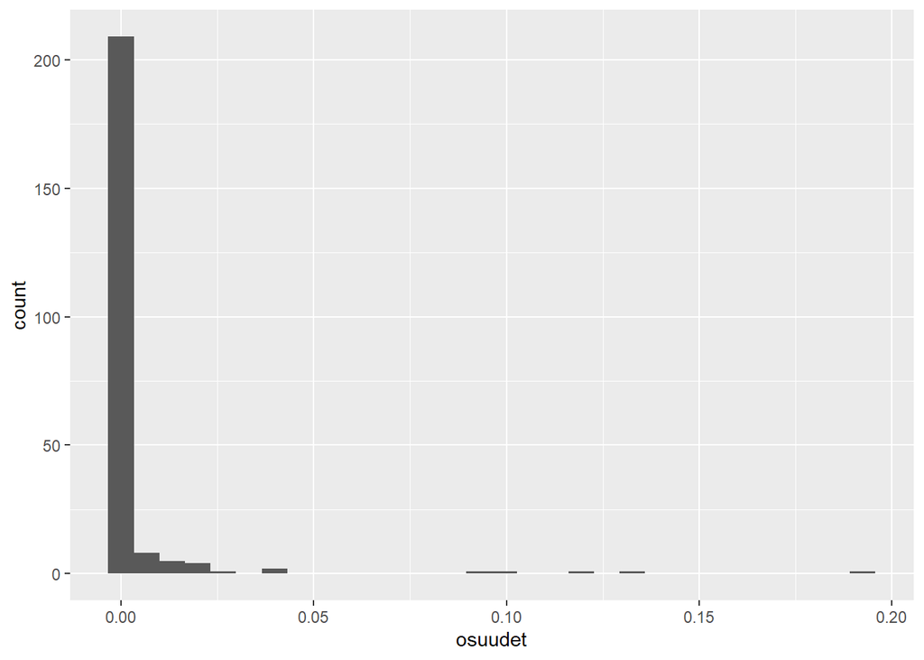

```r
#viljelykasvien keskimääräiset osuudet kaikilta vuosilta
osuudet<-colMeans(data[,15:248])
sp<-names(data[,15:248])
sp<- as.data.frame((cbind(sp,osuudet)),row.names = F)
sp$osuudet<-as.numeric(as.character(sp$osuudet))

#viljelykasvien osuuksien jakauma
ggplot(sp, aes(x=osuudet))+geom_histogram()
```

Vain muutama laji dominoi viljelyosuuksissa.

Yleisimmät viljelykasvit:

```r
#yleisimmät viljelykasvit
sp %>%
  top_n(10, osuudet)
```

```
##       sp    osuudet
## 1  X1110 0.03915448
## 2  X1120 0.19238065
## 3  X1310 0.12194649
## 4  X1320 0.09042679
## 5  X1400 0.13007817
## 6  X4110 0.03935079
## 7  X6121 0.10161367
## 8  X6122 0.02006852
## 9  X6124 0.02164654
## 10 X9400 0.02338377
```

Yleisimmät lajit ovat kevätvehnä (1120), kaura (1400), rehuohra (1310), monivuotiset kuivaheinä-, säilörehu- ja tuorerehunurmet (6121), mallasohra (1320), kevätrypsi (4110) ja syysvehnä (1110).

Kasviryhmien osuudet:

```r
#kasviryhmien keskimääräiset osuudet kaikilta vuosilta
colMeans(data[,251:260])
```

```
##        vege       unkno        spec       fruit        cere        herb
## 0.028861052 0.010546658 0.003109716 0.004511246 0.543042138 0.011517012
##        gras        wint        prot         oil
## 0.260565160 0.060451286 0.017519724 0.055537205
```

Viljat ja nurmet dominoivat. Öljykasvit ja syysviljat tulevat perässä.

Lasken Shannonin diversiteetti-indeksin myös kasviryhmistä. Se saattaa olla järkevämpi mitta kuin kasvikoodeista laskettu indeksi. Sehän saattaa kuvata vain luokittelun kirjoa.

```r
data<-mutate(data, shanG = diversity(data[,251:260],index="shannon"))
```

Jos halutaan vielä tiivistää viljelykasviryhmiä, voidaan lajitella kasvit kahteen ryhmään. Toinen ryhmä (open) käsittää kasvit, jotka ovat keväällä peltosirkkujen pesimäaikaan vasta kylvövaiheessa (tai lyhyellä oraalla?). Toinen ryhmä (cover) käsittää kasvit, jotka ovat keväällä jo pidemmällä kasvussa ja niiden peittävyys on suurempi.

```r
#jos halutaan vielä tiivistää viljelykasveja
data<-mutate(data, open = cere+vege+oil+prot) #pitäisikö vielä lisätä herb, fruit ja spec (ruokohelpi)? Näiden ryhmien osuus on pieni. entäpä 9999?
data<-mutate(data, cover = gras+wint)
```

Huomaa, että open ja cover ovat käytännössä toistensa vastakohdat eli summautuvat melkeinpä yhteen.

### 1.1.5 Pienimuotoisten rakenteiden tiheys

Lasketaan rakennusten, teiden, purojen ja jokien tiheys suhteessa osapopulaation pinta-alaan. Skaalasin muuttujat, koska taloa/km2 ja tiemetriä/km2 ovat hyvin eri skaalalla.

```r
#muutetaan pinta-ala neliökilometreiksi
data$area=data$area/1000000
data<-mutate(data, Abuild = scale(build/area))
data<-mutate(data, Ariver = scale(river/area))
data<-mutate(data, Astream = scale(stream/area))
data<-mutate(data, Aroad = scale(roads/area))
```

Jos halutaan vielä tiivistää kaikki rakenteet yhteen muuttujaan (‘SSS’, small-scale structures):

```r
data<-dplyr::mutate(data, SSS = Abuild+Aroad+Ariver+Astream)
```

## 1.2 Aineiston siistiminen

Karsitaan yksittäiset viljelykasvisarakkeet aineistosta pois, lisätään osapopulaatioiden koordinaatit ja poistetaan aineistosta kaikki ne vuodet, jolloin osapopulaatiota ei käyty tarkistamassa.

```r
data<-data[,c(1:2,4:5,7:8,12:13,249:250,261:269)]

#koordinaatit
koord=dplyr::select(koord,id,X,Y)
data<-left_join(data,koord,by="id")

names(data)
```

```
##  [1] "id"      "year"    "agri5"   "area"    "ndvi"    "prec"    "temp"
##  [8] "terri"   "shan"    "snum"    "neo"     "shanG"   "open"    "cover"
## [15] "Abuild"  "Ariver"  "Astream" "Aroad"   "SSS"     "X"       "Y"
```

```r
#poista aineistosta paikat, joilla ei ole kayty
data=data %>% drop_na("terri")
```

Mukana on siis vielä 21 (osin vaihtoehtoista) muuttujaa.

Tallennetaan aineisto:

```r
#tallennetaan
write.csv(data,"OrtolanBunting.csv",row.names = F)
```